# Part II - Prosper Load Data Exploration

## by Zukhriddin Juliev

## Investigation Overview

Main goal of the investigation is to find factors impacting investor number per loan. Following key insights have been made:

- Investor numbers is highly skewed to lower numbers. However, there are also many loans with investors more than 20.
- Loan size is the key factor in defining investor numbers. Larger loans are correlated with greater investor numbers.
- There is highly negative correlation between interest rates (borrower rate or exected returns) and investor number. These might be explained via size of the loans. Larger loans have lower rates.
- Homeowners are more likely to secure large loans with more investors.
- Loans category of debt consolidation or business are more likely to be funded by multiple investors. This fact can also be explained by loans size for such category and also type of security.

## Dataset Overview

This is ProsperDataset, which contains 113,937 observations of loans with 81 variables along several years. The dataset have information on loans such as profitablity, borrower background, loand conditions, investor number and credit history of borrower and others. This investigation uses data from year 2013 with 15 variables. Final sample consist of 33912 unique loans.

## Distribution of investor numbers

Investor numbers per loan are highly skewed. 25% of loans have 1 investor only. The second most common loans have investor numbers between 20 to 40. There are also many loans with investor number greater than 100. Below is the distribution in raw and log transformed values for loans with investors greater than 5.

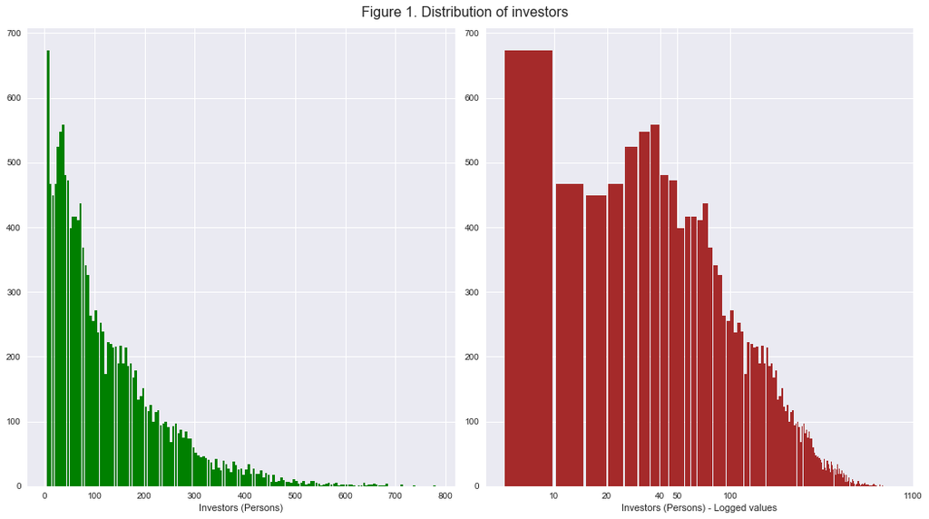

## Loan size, Borrower rate, home owneship - Investor numbers

Loan size is the key factor for a investor numbers. It explains why there is negative correlation between borrowing rate and investor numbers. Larger loans are also more likely to be borrowed by homeowners which can be a sign for secure loan payment. Below scatterplot shows this relationship. Homeowners have more larger sized loans and consequently more loans with multiple investors.

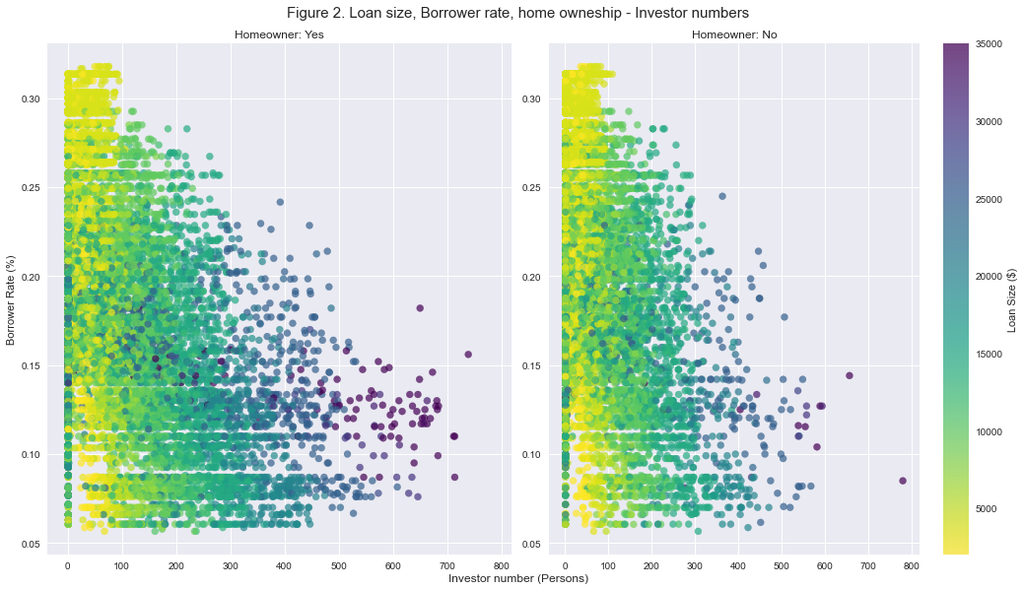

## Loan size, investor number and most frequent loan category

Correlation between investor number and loan size is clear. Among most frequent loans, loans under debt consolidation and business are the ones which attract bigger loans and consequently more investors.

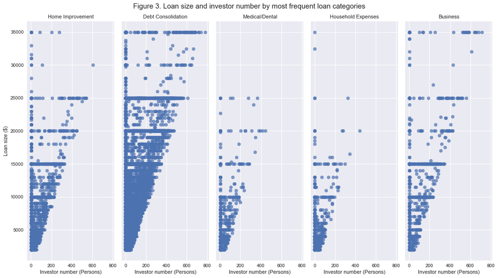